# EDA: abandono y éxito académico

Inferencia Estadística · Grado en Ciencia e Ingeniería de Datos · Curso 2026/27

Autor/a

Sofía Díaz, Diego Sánchez, Shenghui Zhu

Fecha de publicación

26 de octubre de 2026

# 1. DESCRIPCIÓN Y PROCEDENCIA DE LOS DATOS

## 1.1 Origen, Contexto y Marco Institucional

El conjunto de datos analizado se titula *Predict Students’ Dropout and Academic Success* (*Predictor de Éxito y Abandono Escolar*), albergado y disponible públicamente en el **UCI Machine Learning Repository**. Fue donado oficialmente el 12 de diciembre de 2021.

### Contexto y propósito del proyecto

El dataset se enmarca en un proyecto de investigación institucional enfocado en la problemática del fracaso y el abandono escolar temprano en la educación superior. Su contexto responde a la necesidad apremiante de las universidades de comprender los múltiples factores multidimensionales que condicionan la trayectoria académica de los estudiantes. El **propósito central** de este análisis exploratorio es identificar perfiles de riesgo y factores determinantes del rendimiento, contribuyendo a la detección temprana de estudiantes en situación vulnerable para el diseño de políticas preventivas de éxito universitario.

- **Financiación y marco institucional:** El desarrollo del conjunto de datos y la investigación asociada se integran dentro del programa **SATDAP – Capacitación da Administração Pública** (subvención *POCI-05-5762-FSE-000191*, Portugal), lo que refuerza el trasfondo empírico y real de los registros analizados.
- **Licencia de uso:** Creative Commons Attribution 4.0 International (**CC BY 4.0**).
- **Procedencia y recopilación:** Según la documentación oficial de los autores, los datos proceden de la integración de **varias bases de datos disjuntas** procedentes de los sistemas de gestión administrativa de una institución de educación superior portuguesa. Los creadores aplicaron un riguroso preprocesamiento inicial para tratar anomalías, valores atípicos inexplicables y valores faltantes; esto explica la inexistencia de valores perdidos (*Missing Values / NA*) en el dataset bruto suministrado, cuyo tratamiento exacto forma parte del filtrado primario institucional.

## 1.2 ¿Qué representa una observación?

Cada una de las **4.424 filas** que componen el conjunto de datos representa a **un/a estudiante individual** que formalizó su matrícula en una titulación de grado de educación superior (ej. agronomía, diseño, educación, enfermería, periodismo, gestión, trabajo social, tecnologías, etc.).

Cada individuo constituye un vector multidimensional compuesto por **37 variables** (36 variables explicativas y 1 variable objetivo). Esta estructura reúne dos tipologías de información clave:

1. **Información estática de origen:** Datos conocidos de antemano en el momento estricto de la matriculación (trayectoria académica previa, perfil demográfico, factores socioeconómicos y antecedentes familiares).
2. **Información dinámica de progreso académico:** Métricas detalladas sobre el rendimiento y la progresión del estudiante al término del **1.er y del 2.º semestre** (asignaturas matriculadas, convalidadas, evaluadas, aprobadas y calificaciones medias).

## 1.3 Variable Objetivo (`Target`)

La variable objetivo (`Target`) es una variable categórica tricotómica que clasifica el estado final del estudiante al término de la duración normal de la titulación:

| Categoría | Estado Final | Significado Académico |
| --- | --- | --- |
| `Dropout` | **Abandono** | El estudiante ha causado baja o abandonado los estudios de forma prematura. |
| `Enrolled` | **Matriculado** | El estudiante continúa matriculado y cursando la titulación activamente. |
| `Graduate` | **Graduado** | El estudiante ha completado con éxito los créditos y se ha graduado. |

**AdvertenciaNota metodológica sobre el equilibrio de clases**

La propia documentación del repositorio advierte de la existencia de un **fuerte desbalance de clases** en esta variable objetivo, aspecto que deberá ser considerado cuidadosamente durante las fases de visualización y modelado estadístico posterior.

## 1.4 Clasificación Detallada de las Variables Explicativas

Para un mejor rigor analítico, las 36 variables explicativas se estructuran en **cinco dimensiones temáticas**:

### A. Dimensión Sociodemográfica y Familiar

- `Marital status`: Estado civil del estudiante (soltero, casado, viudo, divorciado, unión de hecho, separado legalmente).
- `Nacionality`: Nacionalidad del estudiante (codificada por identificador de país).
- `Gender`: Género del estudiante (variable binaria: $1 = \text{hombre}$, $0 = \text{mujer}$).
- `Age at enrollment`: Edad exacta del estudiante en el momento de la matriculación.
- `International`: Indicador de si el estudiante posee condición internacional (binaria: $1 = \text{sí}$, $0 = \text{no}$).
- `Displaced`: Indicador de si el estudiante se encuentra desplazado de su hogar familiar habitual (binaria).
- `Educational special needs`: Indicador de presencia de necesidades educativas especiales (binaria).
- `Mother’s qualification` / `Father’s qualification`: Nivel de estudios alcanzado por la madre y el padre (variables cualitativas codificadas).
- `Mother’s occupation` / `Father’s occupation`: Ocupación profesional de la madre y el padre (variables cualitativas codificadas).

### B. Dimensión de Acceso y Admisión

- `Application mode`: Vía o procedimiento institucional por el cual el estudiante solicitó la admisión (ej. contingente general, mayores de 23 años, titulares de otros grados, etc.).
- `Application order`: Orden de preferencia (de $0$ a $9$) en que el estudiante solicitó esta titulación específica.
- `Course`: Identificador numérico de la titulación de grado cursada.
- `Daytime/evening attendance`: Régimen u horario de asistencia a las clases (binaria: $1 = \text{diurno}$, $0 = \text{vespertino/nocturno}$).
- `Previous qualification`: Tipo de estudios cursados con anterioridad al acceso universitario.
- `Previous qualification (grade)`: Calificación obtenida en dichos estudios previos (numérica, escala normalizada de $0$ a $200$).
- `Admission grade`: Nota de admisión obtenida para acceder a la universidad (numérica, escala normalizada de $0$ a $200$).

### C. Dimensión Económica y Financiera

- `Debtor`: Indicador de si el estudiante mantiene deudas económicas pendientes con la institución universitaria (binaria).
- `Tuition fees up to date`: Indicador de si el estudiante se encuentra al corriente de pago de las tasas de matrícula vigentes (binaria).
- `Scholarship holder`: Indicador de si el estudiante es beneficiario de una beca institucional de estudios (binaria).

### D. Rendimiento Académico Temporal (1.er y 2.º Semestre)

- **Primer Semestre:**
  - `Curricular units 1st sem (credited)`: Número de asignaturas convalidadas o reconocidas.
  - `Curricular units 1st sem (enrolled)`: Número de asignaturas en las que se matriculó.
  - `Curricular units 1st sem (evaluations)`: Número de actos de evaluación realizados.
  - `Curricular units 1st sem (approved)`: Número de asignaturas efectivamente aprobadas.
  - `Curricular units 1st sem (grade)`: Calificación media ponderada de las asignaturas (escala de $0$ a $20$).
  - `Curricular units 1st sem (without evaluations)`: Número de asignaturas matriculadas sin evaluación (a las que no se presentó).
- **Segundo Semestre:**
  - `Curricular units 2nd sem (credited)`, `(enrolled)`, `(evaluations)`, `(approved)`, `(grade)`, `(without evaluations)`: Métricas homólogas correspondientes al desarrollo del segundo semestre académico.

### E. Dimensión Macroeconómica

- `Unemployment rate`: Tasa de desempleo regional/nacional ($\%$) registrada en el periodo de matriculación.
- `Inflation rate`: Tasa de inflación interanual ($\%$).
- `GDP`: Producto Interior Bruto (PIB), empleado como indicador sintético de la coyuntura y riqueza macroeconómica.

## 1.5 Limitaciones de Partida

El análisis empírico y la posterior interpretación de los resultados deben contextualizarse bajo las siguientes restricciones metodológicas inherentes al origen de los datos:

1. **Sesgo de contexto institucional:** Los datos proceden de **una única institución de educación superior portuguesa**, por lo que las conclusiones obtenidas no son directamente extrapolables a otros marcos universitarios, países o sistemas educativos con normativas diferentes.
2. **Naturaleza observacional:** Al tratarse de un estudio observacional retrospectivo, los análisis estadísticos permitirán identificar asociaciones, dependencias y perfiles de riesgo robustos, pero **no garantizan la inferencia de causalidad directa**.
3. **Horizonte temporal de la categoría `Enrolled`:** Los estudiantes etiquetados como *Enrolled* se encuentran en una situación intermedia cuyo resultado final (éxito o abandono futuro) no queda reflejado en el alcance temporal del dataset.
4. **Preprocesamiento opaco previo:** Aunque el dataset está libre de valores nulos (*NA*), el filtrado y depuración inicial ejecutado por los autores originales limita el control absoluto sobre posibles censuras previas en las observaciones originales.
5. **Desfase temporal predictivo:** Las variables correspondientes al segundo semestre se conocen de forma tardía; si bien son excelentes para describir retrospectivamente el rendimiento anual, poseen limitaciones operativas para la alerta temprana en tiempo real antes de finalizar el curso.

## 1.6 Referencias Bibliográficas Oficiales

- Realinho, V., Vieira Martins, M., Machado, J., & Baptista, L. (2021). *Predict Students’ Dropout and Academic Success* [Dataset]. UCI Machine Learning Repository. https://doi.org/10.24432/C5MC89
- Martins, M. V., Tolledo, D., Machado, J., Baptista, L. M. T., & Realinho, V. (2021). *Early prediction of student’s performance in higher education: a case study*. En *Trends and Applications in Information Systems and Technologies* (WorldCIST 2021).
- Repositorio oficial del conjunto de datos: [UCI Machine Learning Repository - Dataset 697](https://archive.ics.uci.edu/dataset/697/predict+students+dropout+and+academic+success)

# 2. PLANTEAMIENTO INICIAL DEL EDA (METODOLOGÍA Y PLANIFICACIÓN ESTRATÉGICA)

Para evitar un enfoque puramente descriptivo o la generación automatizada de gráficos sin dirección científica, el equipo ha diseñado un **plan de trabajo estructurado**. El análisis parte de una limpieza y verificación exhaustiva del conjunto de datos, y después avanza **de lo simple a lo combinado**, guiado por un hilo conductor central: **¿qué distingue a quienes abandonan de quienes se gradúan, y con qué antelación puede detectarse?**

## 2.1 Fases del Plan de Exploración y Enfoque Metodológico

En cada uno de los pasos descritos a continuación, se seleccionará la técnica estadística adecuada según la tipología de las variables, se comprobarán rigurosamente los supuestos teóricos y **se reportará el tamaño del efecto junto con el correspondiente p-valor**, documentando minuciosamente cada decisión tomada y problema hallado:

### 1. Limpieza y verificación

- Comprobación formal de la lectura correcta del archivo CSV y revisión de la integridad estructural.
- Verificación de nombres de columnas, control de tipologías de variables (conversión de categóricas a factores), detección de filas duplicadas y análisis de posibles valores fuera de rango o incoherencias lógicas entre variables asociadas.

### 2. Visión general

- Descripción univariante de la distribución de la variable objetivo (`Target`) y caracterización global del perfil típico del estudiante universitario al momento de la admisión.

### 3. Comparación variable a variable

- Contraste individual de cada variable explicativa (de ingreso, socioeconómica y académica) frente a la situación final (`Target`) para identificar de forma aislada qué factores muestran una asociación directa con el abandono escolar.

### 4. Combinación de variables

- Análisis multivariante cruzando varias dimensiones de forma simultánea (por ejemplo, evaluar el rendimiento del primer semestre condicionado a la posesión de beca, titulación cursada o situación de deuda económica).
- Permite determinar si el efecto de una variable se modifica en función de otra o si un factor aparenta influir en el abandono únicamente por estar asociado a un tercer elemento.

### 5. Detección temprana

- Comparación evolutiva del poder predictivo y descriptivo: evaluando el horizonte de información disponible estricto en el momento de la matrícula frente a la ganancia informativa aportada por el rendimiento académico del 1.er y del 2.º semestre.

# 3. PREGUNTAS DE PARTIDA E INTERÉS DE LA INVESTIGACIÓN

Para dotar al EDA de profundidad analítica, la exploración contrastará las siguientes hipótesis clave:

**Nota1. Distribución de la variable objetivo y desbalance de clases**

- **Pregunta:** ¿Cómo se distribuyen los estudiantes según su situación académica final (abandono, matriculado o graduado) y hasta qué punto están desbalanceadas las clases?
- **Objetivo:** Cuantificar el tamaño absoluto y relativo de cada grupo (`Dropout`, `Enrolled`, `Graduate`) para decidir cómo tratar la categoría *Enrolled* (cuyo resultado final no es conocido dentro del horizonte del dataset) y determinar si las comparaciones estadísticas posteriores deben basarse en porcentajes condicionados por grupo en lugar de recuentos absolutos.

**Nota2. El umbral crítico del primer semestre frente a la nota de acceso**

- **Pregunta:** ¿Hasta qué punto el rendimiento académico acumulado en el primer semestre (`Curricular units 1st sem (approved)` y su nota media) actúa como un discriminador más potente del éxito o abandono frente a la nota de admisión universitaria (`Admission grade`)?
- **Objetivo:** Evaluar la capacidad predictiva relativa entre la trayectoria previa del estudiante (nota de admisión) y su adaptación inicial al contexto universitario (desempeño en el primer semestre) para determinar en qué momento se genera la brecha crítica de abandono.

**Nota3. Vulnerabilidad financiera y su impacto real**

- **Pregunta:** ¿Existe una dependencia estadísticamente significativa entre el estado de impago de tasas (`Debtor`) y la beca institucional (`Scholarship holder`) respecto al abandono, y cómo interactúan con las capacidades previas del alumno?
- **Objetivo:** Cuantificar el impacto de las restricciones socioeconómicas y la efectividad de las becas como mecanismo protector frente al riesgo de abandono escolar temprano, aislando el factor económico del rendimiento académico puro.

**Nota4. Factores demográficos y modalidad de estudio**

- **Pregunta:** ¿De qué manera la edad al matricularse (`Age at enrollment`) y la modalidad de asistencia (`Daytime/evening attendance`) modulan la propensión al abandono universitario?
- **Objetivo:** Identificar perfiles sociodemográficos de mayor vulnerabilidad (tales como estudiantes maduros o matriculados en régimen nocturno) para comprender si la incompatibilidad con responsabilidades laborales o familiares afecta de forma diferencial al éxito académico.

**Nota5. Sensibilidad macroeconómica del entorno**

- **Pregunta:** ¿Ejercen las variables macroeconómicas regionales (`Unemployment rate`, `Inflation rate`, `GDP`) un efecto apreciable en las tasas globales de éxito académico de las distintas cohortes?
- **Objetivo:** Determinar si el contexto socioeconómico externo actúa como un factor coyuntural que condiciona la continuidad universitaria, incentivando la salida prematura hacia el mercado laboral en momentos de variación económica.

# 4. PROCESO

## 4.0 Limpieza

**Código**

```r
# Librerías
library(tidyverse)
library(janitor)
library(caret)
library(ggplot2)
library(dplyr)
```

**Código**

```r
# 1. Lectura y nombres
datos_raw <- read.csv2("data.csv", check.names = FALSE,
                       fileEncoding = "UTF-8-BOM", dec = ".")

datos <- datos_raw %>%
  clean_names() %>%
  rename(nationality = nacionality) %>%
  rename_with(~ str_replace(.x, "^mother.*qualification$", "mother_qualification")) %>%
  rename_with(~ str_replace(.x, "^father.*qualification$", "father_qualification")) %>%
  rename_with(~ str_replace(.x, "^mother.*occupation$",   "mother_occupation")) %>%
  rename_with(~ str_replace(.x, "^father.*occupation$",   "father_occupation"))

numericas <- c("age_at_enrollment", "application_order",
               "previous_qualification_grade", "admission_grade",
               "unemployment_rate", "inflation_rate", "gdp")

datos <- datos %>%
  mutate(across(c(all_of(numericas), contains("curricular_units")),
                ~ as.numeric(gsub(",", ".", .x))))

dim(datos)
```

```
[1] 4424   37
```

**Código**

```r
names(datos)
```

```
 [1] "marital_status"
 [2] "application_mode"
 [3] "application_order"
 [4] "course"
 [5] "daytime_evening_attendance"
 [6] "previous_qualification"
 [7] "previous_qualification_grade"
 [8] "nationality"
 [9] "mother_qualification"
[10] "father_qualification"
[11] "mother_occupation"
[12] "father_occupation"
[13] "admission_grade"
[14] "displaced"
[15] "educational_special_needs"
```

[output cut: 22 more lines]

**Código**

```r
# 2. Faltantes y duplicados
sum(is.na(datos))
```

```
[1] 0
```

**Código**

```r
colSums(is.na(datos))[colSums(is.na(datos)) > 0]
```

```
named numeric(0)
```

**Código**

```r
sum(duplicated(datos))
```

```
[1] 0
```

**Código**

```r
# 3. Tipos de variable
glimpse(datos)
```

```
Rows: 4,424
Columns: 37
$ marital_status                               <int> 1, 1, 1, 1, 2, 2, 1, 1, 1…
$ application_mode                             <int> 17, 15, 1, 17, 39, 39, 1,…
$ application_order                            <dbl> 5, 1, 5, 2, 1, 1, 1, 4, 3…
$ course                                       <int> 171, 9254, 9070, 9773, 80…
$ daytime_evening_attendance                   <int> 1, 1, 1, 1, 0, 0, 1, 1, 1…
$ previous_qualification                       <int> 1, 1, 1, 1, 1, 19, 1, 1, …
$ previous_qualification_grade                 <dbl> 122.0, 160.0, 122.0, 122.…
$ nationality                                  <int> 1, 1, 1, 1, 1, 1, 1, 1, 6…
$ mother_qualification                         <int> 19, 1, 37, 38, 37, 37, 19…
$ father_qualification                         <int> 12, 3, 37, 37, 38, 37, 38…
$ mother_occupation                            <int> 5, 3, 9, 5, 9, 9, 7, 9, 9…
$ father_occupation                            <int> 9, 3, 9, 3, 9, 7, 10, 9, …
$ admission_grade                              <dbl> 127.3, 142.5, 124.8, 119.…
```

[output cut: 24 more lines]

**Código**

```r
# 4. Categorías de Target
table(datos$target, useNA = "ifany")
```

```
 Dropout Enrolled Graduate
    1421      794     2209
```

**Código**

```r
# 5. Valores fuera de rango
binarias <- c("daytime_evening_attendance", "displaced", "educational_special_needs",
              "debtor", "tuition_fees_up_to_date", "gender", "scholarship_holder",
              "international")

categoricas <- c("marital_status", "application_mode", "course", "previous_qualification",
                 "nationality", "mother_qualification", "father_qualification",
                 "mother_occupation", "father_occupation")

# Control: si devuelve character(0), todos los nombres existen
setdiff(c(binarias, categoricas), names(datos))
```

```
character(0)
```

**Código**

```r
map(datos[binarias], ~ sort(unique(.x)))
```

```
$daytime_evening_attendance
[1] 0 1

$displaced
[1] 0 1

$educational_special_needs
[1] 0 1

$debtor
[1] 0 1

$tuition_fees_up_to_date
[1] 0 1

$gender
[1] 0 1

$scholarship_holder
[1] 0 1

$international
[1] 0 1
```

**Código**

```r
summary(datos %>% select(age_at_enrollment, application_order,
                         previous_qualification_grade, admission_grade,
                         contains("curricular_units"),
                         unemployment_rate, inflation_rate, gdp))
```

```
 age_at_enrollment application_order previous_qualification_grade
 Min.   :17.00     Min.   :0.000     Min.   : 95.0
 1st Qu.:19.00     1st Qu.:1.000     1st Qu.:125.0
 Median :20.00     Median :1.000     Median :133.1
 Mean   :23.27     Mean   :1.728     Mean   :132.6
 3rd Qu.:25.00     3rd Qu.:2.000     3rd Qu.:140.0
 Max.   :70.00     Max.   :9.000     Max.   :190.0
 admission_grade curricular_units_1st_sem_credited
 Min.   : 95.0   Min.   : 0.00
 1st Qu.:117.9   1st Qu.: 0.00
 Median :126.1   Median : 0.00
 Mean   :127.0   Mean   : 0.71
 3rd Qu.:134.8   3rd Qu.: 0.00
 Max.   :190.0   Max.   :20.00
 curricular_units_1st_sem_enrolled curricular_units_1st_sem_evaluations
 Min.   : 0.000                    Min.   : 0.000
 1st Qu.: 5.000                    1st Qu.: 6.000
 Median : 6.000                    Median : 8.000
 Mean   : 6.271                    Mean   : 8.299
 3rd Qu.: 7.000                    3rd Qu.:10.000
 Max.   :26.000                    Max.   :45.000
 curricular_units_1st_sem_approved curricular_units_1st_sem_grade
 Min.   : 0.000                    Min.   : 0.00
 1st Qu.: 3.000                    1st Qu.:11.00
 Median : 5.000                    Median :12.29
 Mean   : 4.707                    Mean   :10.64
 3rd Qu.: 6.000                    3rd Qu.:13.40
 Max.   :26.000                    Max.   :18.88
 curricular_units_1st_sem_without_evaluations curricular_units_2nd_sem_credited
 Min.   : 0.0000                              Min.   : 0.0000
 1st Qu.: 0.0000                              1st Qu.: 0.0000
 Median : 0.0000                              Median : 0.0000
 Mean   : 0.1377                              Mean   : 0.5418
 3rd Qu.: 0.0000                              3rd Qu.: 0.0000
 Max.   :12.0000                              Max.   :19.0000
 curricular_units_2nd_sem_enrolled curricular_units_2nd_sem_evaluations
 Min.   : 0.000                    Min.   : 0.000
 1st Qu.: 5.000                    1st Qu.: 6.000
 Median : 6.000                    Median : 8.000
 Mean   : 6.232                    Mean   : 8.063
```

[output cut: 8 more lines]

```
 Max.   :20.000                    Max.   :18.57
 curricular_units_2nd_sem_without_evaluations unemployment_rate
 Min.   : 0.0000                              Min.   : 7.60
 1st Qu.: 0.0000                              1st Qu.: 9.40
 Median : 0.0000                              Median :11.10
 Mean   : 0.1503                              Mean   :11.57
 3rd Qu.: 0.0000                              3rd Qu.:13.90
 Max.   :12.0000                              Max.   :16.20
 inflation_rate        gdp
 Min.   :-0.800   Min.   :-4.060000
 1st Qu.: 0.300   1st Qu.:-1.700000
 Median : 1.400   Median : 0.320000
 Mean   : 1.228   Mean   : 0.001969
 3rd Qu.: 2.600   3rd Qu.: 1.790000
 Max.   : 3.700   Max.   : 3.510000
```

**Código**

```r
# 6. Coherencia entre variables
sum(datos$curricular_units_1st_sem_approved > datos$curricular_units_1st_sem_enrolled)
```

```
[1] 0
```

**Código**

```r
sum(datos$curricular_units_2nd_sem_approved > datos$curricular_units_2nd_sem_enrolled)
```

```
[1] 0
```

**Código**

```r
sum(datos$curricular_units_1st_sem_enrolled == 0)
```

```
[1] 180
```

**Código**

```r
sum(datos$curricular_units_2nd_sem_enrolled == 0)
```

```
[1] 180
```

**Código**

```r
sum(datos$curricular_units_1st_sem_grade == 0 & datos$curricular_units_1st_sem_evaluations > 0)
```

```
[1] 369
```

**Código**

```r
# 7. Conversión de tipos
datos_limpio <- datos %>%
  mutate(
    across(all_of(setdiff(binarias, c("gender", "daytime_evening_attendance"))), as.factor),
    across(all_of(categoricas), as.factor),
    gender = factor(gender, levels = c(0, 1), labels = c("Mujer", "Hombre")),
    daytime_evening_attendance = factor(daytime_evening_attendance,
                                        levels = c(0, 1), labels = c("Vespertino", "Diurno")),
    target = factor(target, levels = c("Dropout", "Enrolled", "Graduate"))
  )

str(datos_limpio$target)
```

```
 Factor w/ 3 levels "Dropout","Enrolled",..: 1 3 1 3 3 3 3 1 3 1 ...
```

**Código**

```r
glimpse(datos_limpio)
```

```
Rows: 4,424
Columns: 37
$ marital_status                               <fct> 1, 1, 1, 1, 2, 2, 1, 1, 1…
$ application_mode                             <fct> 17, 15, 1, 17, 39, 39, 1,…
$ application_order                            <dbl> 5, 1, 5, 2, 1, 1, 1, 4, 3…
$ course                                       <fct> 171, 9254, 9070, 9773, 80…
$ daytime_evening_attendance                   <fct> Diurno, Diurno, Diurno, D…
$ previous_qualification                       <fct> 1, 1, 1, 1, 1, 19, 1, 1, …
$ previous_qualification_grade                 <dbl> 122.0, 160.0, 122.0, 122.…
$ nationality                                  <fct> 1, 1, 1, 1, 1, 1, 1, 1, 6…
$ mother_qualification                         <fct> 19, 1, 37, 38, 37, 37, 19…
$ father_qualification                         <fct> 12, 3, 37, 37, 38, 37, 38…
$ mother_occupation                            <fct> 5, 3, 9, 5, 9, 9, 7, 9, 9…
$ father_occupation                            <fct> 9, 3, 9, 3, 9, 7, 10, 9, …
$ admission_grade                              <dbl> 127.3, 142.5, 124.8, 119.…
```

[output cut: 24 more lines]

**Decisiones y problemas encontrados en la limpieza**

- **Lectura del archivo:** el CSV usa `;` como separador de campos y `.` como separador decimal. Con `read.csv2()` hay que indicar `dec = "."`; sin ello, las variables decimales (notas y variables macroeconómicas) se leían como texto y los cálculos numéricos fallaban.
- **Nombres de columnas:** `clean_names()` los normaliza. El nombre de `Daytime/evening attendance` contenía un tabulador oculto y `Nacionality` es una errata del original, que se corrige a `nationality`.
- **Integridad:** el archivo tiene 4.424 filas y 37 columnas, sin valores faltantes y sin filas duplicadas, como indica la documentación. Las variables binarias solo contienen 0 y 1 y los rangos son plausibles (edad de 17 a 70 años, notas de 95 a 190 sobre 200, desempleo entre el 7,6 % y el 16,2 %).
- **Coherencia entre variables:** ninguna asignatura aprobada supera a las matriculadas. Hay 180 estudiantes sin asignaturas matriculadas en el 1.er semestre (77 *Dropout*, 75 *Graduate* y 28 *Enrolled*) y sin convalidaciones que lo expliquen; resulta llamativo que 75 consten como graduados. No se eliminan porque no hay un criterio documentado para considerarlos errores, pero se deja constancia de esta posible anomalía del origen de los datos.
- **Notas medias iguales a 0:** 369 estudiantes tienen nota media 0 en el 1.er semestre habiendo sido evaluados. En todos ellos las asignaturas aprobadas son 0, así que el 0 significa «ninguna aprobada» y no un dato faltante. Se mantiene como 0.
- **Tipos de variable:** las variables binarias y las categóricas codificadas se convierten a factor (con etiquetas en `gender` y en la modalidad de asistencia), y `Target` se ordena como *Dropout*, *Enrolled*, *Graduate*.

## 4.1 Pregunta 1: Distribución de la situación académica final

### Planteamiento y Justificación

El objetivo es cuantificar el tamaño de cada grupo de `Target` para decidir cómo tratar la categoría `Enrolled` (estudiantes que siguen matriculados y cuyo resultado final todavía no se conoce) y para saber si las comparaciones posteriores deben hacerse con porcentajes dentro de cada grupo en lugar de recuentos absolutos. Si las clases estuvieran muy desbalanceadas, comparar recuentos entre grupos favorecería siempre a la categoría más numerosa.

**Código**

```r
# 1. Tabla de frecuencias absolutas y relativas
resumen <- datos_limpio %>%
  count(target) %>%
  mutate(porcentaje = n / sum(n) * 100)

print("Distribución de los estudiantes según su situación académica final:")
```

```
[1] "Distribución de los estudiantes según su situación académica final:"
```

**Código**

```r
print(resumen)
```

```
    target    n porcentaje
1  Dropout 1421   32.12025
2 Enrolled  794   17.94756
3 Graduate 2209   49.93219
```

**Código**

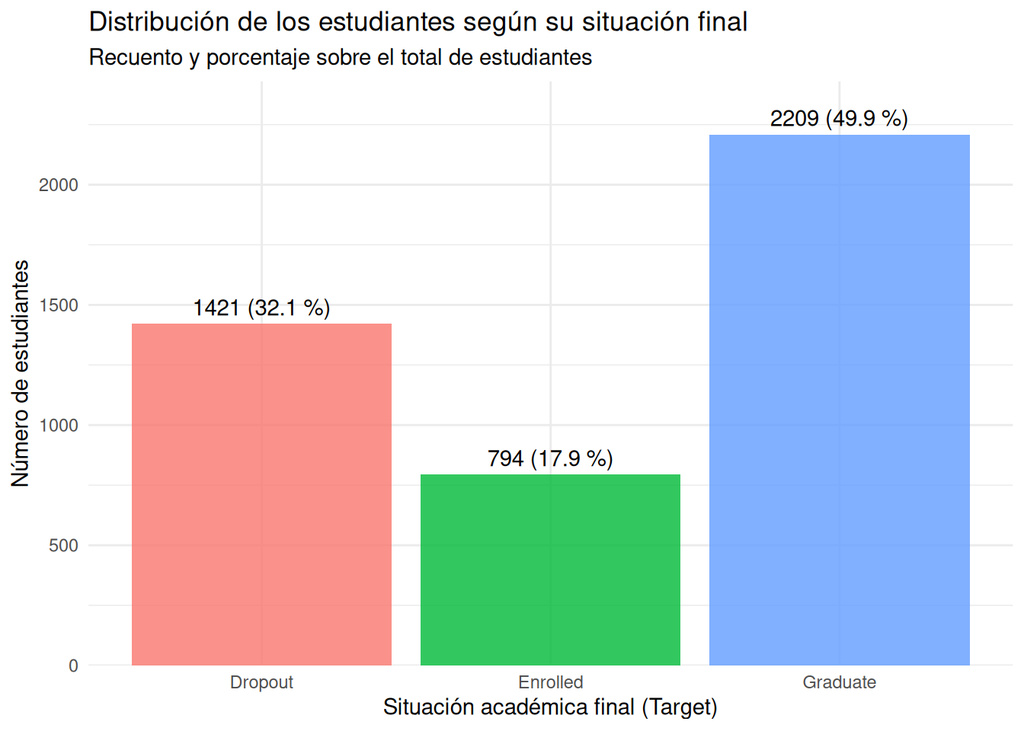

```r
# 2. Gráfico de barras con recuentos y porcentajes
ggplot(resumen, aes(x = target, y = n, fill = target)) +
  geom_col(alpha = 0.8, show.legend = FALSE) +
  geom_text(aes(label = paste0(n, " (", round(porcentaje, 1), " %)")),
            vjust = -0.5) +
  scale_y_continuous(expand = expansion(mult = c(0, 0.1))) +
  labs(title = "Distribución de los estudiantes según su situación final",
       subtitle = "Recuento y porcentaje sobre el total de estudiantes",
       x = "Situación académica final (Target)",
       y = "Número de estudiantes") +
  theme_minimal()
```

**Código**

```r
# 3. Medidas de desbalance entre clases
n_clases <- nrow(resumen)

desbalance <- tibble(
  clase_mayoritaria = as.character(resumen$target[which.max(resumen$n)]),
  clase_minoritaria = as.character(resumen$target[which.min(resumen$n)]),
  ratio_mayor_menor = max(resumen$n) / min(resumen$n),
  pct_minoritaria   = min(resumen$porcentaje),
  pct_esperado_si_equilibrado = 100 / n_clases
)

print("Medidas de desbalance:")
```

```
[1] "Medidas de desbalance:"
```

**Código**

```r
print(desbalance)
```

```
# A tibble: 1 × 5
  clase_mayoritaria clase_minoritaria ratio_mayor_menor pct_minoritaria
  <chr>             <chr>                         <dbl>           <dbl>
1 Graduate          Enrolled                       2.78            17.9
# ℹ 1 more variable: pct_esperado_si_equilibrado <dbl>
```

**Código**

```r
# Contraste chi-cuadrado de bondad de ajuste: ¿son las tres clases equiprobables?
test_equilibrio <- chisq.test(table(datos_limpio$target))
print(test_equilibrio)
```

```
    Chi-squared test for given probabilities

data:  table(datos_limpio$target)
X-squared = 681.8, df = 2, p-value < 2.2e-16
```

**Código**

```r
# 4. Distribución si se excluye Enrolled (solo resultados finales conocidos)
resumen_conocidos <- datos_limpio %>%
  filter(target != "Enrolled") %>%
  count(target) %>%
  mutate(porcentaje = n / sum(n) * 100)

print("Distribución considerando solo Dropout y Graduate:")
```

```
[1] "Distribución considerando solo Dropout y Graduate:"
```

**Código**

```r
print(resumen_conocidos)
```

```
    target    n porcentaje
1  Dropout 1421   39.14601
2 Graduate 2209   60.85399
```

**Código**

```r
# Tasa de abandono sobre los estudiantes con resultado final conocido
resumen_conocidos %>% filter(target == "Dropout") %>% pull(porcentaje)
```

```
[1] 39.14601
```

**Resultado y decisión:** 2.209 estudiantes se gradúan (49,9 %), 1.421 abandonan (32,1 %) y 794 continúan matriculados (18,0 %). La clase mayoritaria es 2,78 veces mayor que la minoritaria y el contraste chi-cuadrado rechaza que las tres sean equiprobables, por lo que el desbalance es moderado. Como el resultado final de *Enrolled* se desconoce, se mantiene en el análisis pero se interpreta con cautela, y las comparaciones se hacen con porcentajes dentro de cada grupo.

## 4.2 Pregunta 2: El umbral crítico del primer semestre frente a la nota de acceso

### Planteamiento y Justificación

El objetivo de este análisis es evaluar si la adaptación temprana al entorno universitario (medida a través del rendimiento en el primer semestre) es un discriminador del éxito o abandono final más potente que la nota previa de admisión (`Admission grade`). Para ello, analizaremos la distribución de las asignaturas aprobadas en el primer semestre y la nota media ponderada, comparándolas según el estado final del estudiante (`Target`).

**Código**

```r
# 1. Resumen estadístico de asignaturas aprobadas en el 1.er semestre por Target
resumen_sem1_aprobadas <- datos_limpio %>%
  group_by(target) %>%
  summarise(
    n_estudiantes = n(),
    media_aprobadas = mean(curricular_units_1st_sem_approved, na.rm = TRUE),
    mediana_aprobadas = median(curricular_units_1st_sem_approved, na.rm = TRUE),
    iqr_aprobadas = IQR(curricular_units_1st_sem_approved, na.rm = TRUE),
    desv_tip_aprobadas = sd(curricular_units_1st_sem_approved, na.rm = TRUE)
  )

print("Resumen estadístico de asignaturas aprobadas en el 1.er semestre:")
```

```
[1] "Resumen estadístico de asignaturas aprobadas en el 1.er semestre:"
```

**Código**

```r
print(resumen_sem1_aprobadas)
```

```
# A tibble: 3 × 6
  target   n_estudiantes media_aprobadas mediana_aprobadas iqr_aprobadas
  <fct>            <int>           <dbl>             <dbl>         <dbl>
1 Dropout           1421            2.55                 2             4
2 Enrolled           794            4.32                 5             3
3 Graduate          2209            6.23                 6             2
# ℹ 1 more variable: desv_tip_aprobadas <dbl>
```

**Código**

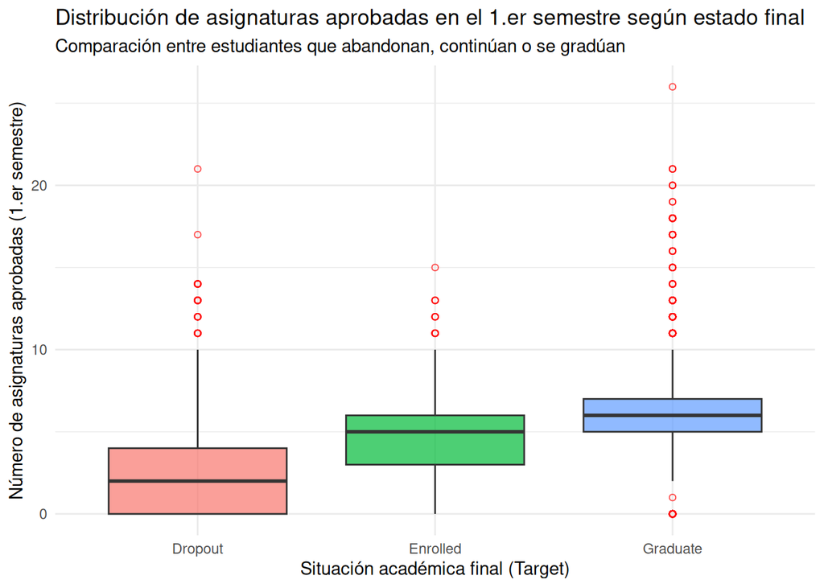

```r
# 2. Gráfico de cajas (Boxplot) para comparar las asignaturas aprobadas por Target
ggplot(datos_limpio, aes(x = target, y = curricular_units_1st_sem_approved, fill = target)) +
  geom_boxplot(alpha = 0.7, outlier.colour = "red", outlier.shape = 1) +
  labs(
    title = "Distribución de asignaturas aprobadas en el 1.er semestre según estado final",
    subtitle = "Comparación entre estudiantes que abandonan, continúan o se gradúan",
    x = "Situación académica final (Target)",
    y = "Número de asignaturas aprobadas (1.er semestre)"
  ) +
  theme_minimal() +
  theme(legend.position = "none")
```

**Código**

```r
# 3. Contraste numérico de la nota de admisión frente a la nota media del 1.er semestre
resumen_notas <- datos_limpio %>%
  group_by(target) %>%
  summarise(
    media_nota_admision = mean(admission_grade, na.rm = TRUE),
    media_nota_sem1 = mean(curricular_units_1st_sem_grade, na.rm = TRUE)
  )

print("Comparativa de notas de admisión frente a notas del 1.er semestre:")
```

```
[1] "Comparativa de notas de admisión frente a notas del 1.er semestre:"
```

**Código**

```r
print(resumen_notas)
```

```
# A tibble: 3 × 3
  target   media_nota_admision media_nota_sem1
  <fct>                  <dbl>           <dbl>
1 Dropout                 125.            7.26
2 Enrolled                126.           11.1
3 Graduate                129.           12.6
```

**Código**

```r
# 4. Contraste y tamaño del efecto (Dropout frente a Graduate)
# La d de Cohen estandariza la diferencia de medias, lo que permite comparar
# variables medidas en escalas distintas (recuento de asignaturas vs nota sobre 200)
cohen_d <- function(x, grupo) {
  g  <- levels(grupo)
  x1 <- x[grupo == g[1]]
  x2 <- x[grupo == g[2]]
  sp <- sqrt(((length(x1) - 1) * var(x1) + (length(x2) - 1) * var(x2)) /
               (length(x1) + length(x2) - 2))
  (mean(x1) - mean(x2)) / sp
}

dg <- datos_limpio %>%
  filter(target %in% c("Dropout", "Graduate")) %>%
  droplevels()

vars_q2 <- c("admission_grade",
             "curricular_units_1st_sem_approved",
             "curricular_units_1st_sem_grade")

efecto_q2 <- map_dfr(vars_q2, function(v) {
  tibble(variable   = v,
         d_cohen    = cohen_d(dg[[v]], dg$target),
         p_wilcoxon = wilcox.test(dg[[v]] ~ dg$target, exact = FALSE)$p.value)
})

print("Tamaño del efecto (Dropout - Graduate) y contraste de Wilcoxon:")
```

```
[1] "Tamaño del efecto (Dropout - Graduate) y contraste de Wilcoxon:"
```

**Código**

```r
print(efecto_q2)
```

```
# A tibble: 3 × 3
  variable                          d_cohen p_wilcoxon
  <chr>                               <dbl>      <dbl>
1 admission_grade                    -0.264  3.25e- 15
2 curricular_units_1st_sem_approved  -1.37   7.46e-302
3 curricular_units_1st_sem_grade     -1.25   1.96e-218
```

**Código**

```r
# 5. Tasa de abandono según el número de asignaturas aprobadas en el 1.er semestre
tasa_aprobadas <- datos_limpio %>%
  mutate(tramo_aprobadas = cut(curricular_units_1st_sem_approved,
                               breaks = c(-1, 0, 2, 4, 6, Inf),
                               labels = c("0", "1-2", "3-4", "5-6", "7 o más"))) %>%
  group_by(tramo_aprobadas) %>%
  summarise(n = n(), tasa_abandono = mean(target == "Dropout") * 100)

print("Tasa de abandono (%) según asignaturas aprobadas en el 1.er semestre:")
```

```
[1] "Tasa de abandono (%) según asignaturas aprobadas en el 1.er semestre:"
```

**Código**

```r
print(tasa_aprobadas)
```

```
# A tibble: 5 × 3
  tramo_aprobadas     n tasa_abandono
  <fct>           <int>         <dbl>
1 0                 718          79.4
2 1-2               287          71.4
3 3-4               702          42.3
4 5-6              1894          13.8
5 7 o más           823          10.6
```

**Resultado y decisión:** Las medias de asignaturas aprobadas son 6,23 (*Graduate*), 4,32 (*Enrolled*) y 2,55 (*Dropout*), mientras que la nota de admisión apenas varía (128,8, 125,5 y 125,0). Como las variables están en escalas distintas, la comparación se hace con la d de Cohen (*Dropout* frente a *Graduate*): |d| = 1,37 para las asignaturas aprobadas y 1,25 para la nota media del 1.er semestre, frente a 0,26 para la nota de admisión. Todas las diferencias son significativas (Wilcoxon, p < 0,001), pero solo las del primer semestre tienen un efecto grande. Además, el abandono no crece de forma gradual: es del 79,4 % con 0 asignaturas aprobadas y del 71,4 % con 1-2, baja al 42,3 % con 3-4 y se queda en torno al 10-14 % a partir de 5. El tramo decisivo está, por tanto, entre 1-2 y 5-6 asignaturas aprobadas. Para comparar grupos se usan contrastes no paramétricos (Wilcoxon aquí y Kruskal-Wallis en 4.5), porque varias variables son recuentos o tienen distribuciones asimétricas, como se aprecia en los diagramas de cajas y en el violín de la edad, y por eso no se asume normalidad.

## 4.3 Pregunta 3: Vulnerabilidad financiera y su impacto real

### Planteamiento y Justificación

Estudiamos la relación entre la restricción económica (ser deudor de tasas universitarias: `debtor` y no disponer de beca: `scholarship_holder`) y la probabilidad de abandono escolar (`Dropout`). El objetivo es cuantificar si el impago o la falta de ayudas multiplican el riesgo de abandono y si actúan de forma independiente al rendimiento académico.

**Código**

```r
# 1. Tabla de contingencia cruzada entre condición de Deudor y Target (frecuencias y porcentajes)
tabla_deuda <- table(datos_limpio$debtor, datos_limpio$target)
prop_deuda <- prop.table(tabla_deuda, margin = 1) * 100 # Porcentajes por filas

print("Frecuencias absolutas (Deudor vs Target):")
```

```
[1] "Frecuencias absolutas (Deudor vs Target):"
```

**Código**

```r
print(tabla_deuda)
```

```
    Dropout Enrolled Graduate
  0    1109      704     2108
  1     312       90      101
```

**Código**

```r
print("Proporciones por filas (%):")
```

```
[1] "Proporciones por filas (%):"
```

**Código**

```r
print(round(prop_deuda, 2))
```

```
    Dropout Enrolled Graduate
  0   28.28    17.95    53.76
  1   62.03    17.89    20.08
```

**Código**

```r
# 2. Prueba estadística de Chi-cuadrado para evaluar independencia
test_chi_deuda <- chisq.test(tabla_deuda)
print(test_chi_deuda)
```

```
    Pearson's Chi-squared test

data:  tabla_deuda
X-squared = 259.33, df = 2, p-value < 2.2e-16
```

**Código**

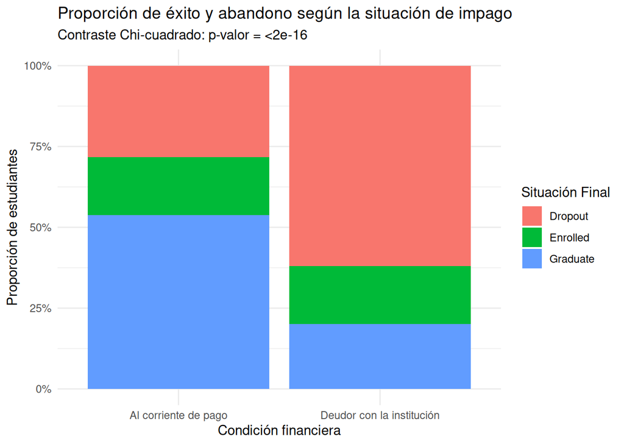

```r
# 3. Gráfico de barras agrupadas: Deuda y Estado Final
ggplot(datos_limpio, aes(x = debtor, fill = target)) +
  geom_bar(position = "fill") +
  scale_y_continuous(labels = scales::percent) +
  scale_x_discrete(labels = c("0" = "Al corriente de pago", "1" = "Deudor con la institución")) +
  labs(
    title = "Proporción de éxito y abandono según la situación de impago",
    subtitle = paste("Contraste Chi-cuadrado: p-valor =",
                     format.pval(test_chi_deuda$p.value, digits = 3, eps = 2.2e-16)),
    x = "Condición financiera",
    y = "Proporción de estudiantes",
    fill = "Situación Final"
  ) +
  theme_minimal()
```

**Código**

```r
# 4. Beca: porcentajes por fila, contraste y tamaño del efecto (V de Cramér)
tabla_beca <- table(datos_limpio$scholarship_holder, datos_limpio$target)

print("Proporciones por filas (%) (Beca vs Target):")
```

```
[1] "Proporciones por filas (%) (Beca vs Target):"
```

**Código**

```r
print(round(prop.table(tabla_beca, margin = 1) * 100, 2))
```

```
    Dropout Enrolled Graduate
  0   38.71    19.97    41.32
  1   12.19    11.83    75.98
```

**Código**

```r
print(chisq.test(tabla_beca))
```

```
    Pearson's Chi-squared test

data:  tabla_beca
X-squared = 409.94, df = 2, p-value < 2.2e-16
```

**Código**

```r
# V de Cramér: 0 = sin asociación, 1 = asociación perfecta
cramers_v <- function(tabla) {
  chi2 <- unname(chisq.test(tabla, correct = FALSE)$statistic)
  sqrt(chi2 / (sum(tabla) * (min(dim(tabla)) - 1)))
}

efecto_financiero <- tibble(
  variable = c("debtor", "scholarship_holder"),
  v_cramer = c(cramers_v(tabla_deuda), cramers_v(tabla_beca))
)
print("Tamaño del efecto (V de Cramér):")
```

```
[1] "Tamaño del efecto (V de Cramér):"
```

**Código**

```r
print(efecto_financiero)
```

```
# A tibble: 2 × 2
  variable           v_cramer
  <chr>                 <dbl>
1 debtor                0.242
2 scholarship_holder    0.304
```

**Código**

```r
# 5. Combinación de variables: tasa de abandono según deuda y beca a la vez
# (debtor: 1 = deudor; scholarship_holder: 1 = becado)
tasa_deuda_beca <- datos_limpio %>%
  group_by(debtor, scholarship_holder) %>%
  summarise(n = n(), tasa_abandono = mean(target == "Dropout") * 100,
            .groups = "drop")

print("Tasa de abandono (%) según deuda y beca:")
```

```
[1] "Tasa de abandono (%) según deuda y beca:"
```

**Código**

```r
print(tasa_deuda_beca)
```

```
# A tibble: 4 × 4
  debtor scholarship_holder     n tasa_abandono
  <fct>  <fct>              <int>         <dbl>
1 0      0                   2906          34.6
2 0      1                   1015          10.1
3 1      0                    419          67.1
4 1      1                     84          36.9
```

**Código**

```r
# 6. ¿Actúan de forma independiente al rendimiento? Regresión logística
# Dropout (1) frente a Graduate (0); la nota de admisión se expresa por cada 10 puntos
datos_glm <- datos_limpio %>%
  filter(target != "Enrolled") %>%
  mutate(abandono = as.integer(target == "Dropout"),
         admission_grade_10 = admission_grade / 10)

modelo_abandono <- glm(abandono ~ debtor + scholarship_holder +
                         curricular_units_1st_sem_approved + admission_grade_10,
                       data = datos_glm, family = binomial)

# Odds ratio con intervalo de confianza al 95 % (Wald)
or_tabla <- exp(cbind(OR = coef(modelo_abandono), confint.default(modelo_abandono)))
print("Odds ratio de abandono (frente a graduarse):")
```

```
[1] "Odds ratio de abandono (frente a graduarse):"
```

**Código**

```r
print(round(or_tabla, 2))
```

```
                                     OR 2.5 % 97.5 %
(Intercept)                       79.18 35.01 179.06
debtor1                            6.44  4.76   8.72
scholarship_holder1                0.23  0.18   0.29
curricular_units_1st_sem_approved  0.58  0.55   0.60
admission_grade_10                 0.84  0.79   0.89
```

**Resultado y decisión:** Los deudores abandonan el 62,0 % de las veces frente al 28,3 % de quienes están al corriente de pago, y los becados el 12,2 % frente al 38,7 % de los no becados. Ambas asociaciones son significativas (p < 0,001) y de tamaño moderado (V de Cramér de 0,24 para la deuda y 0,30 para la beca). Combinando ambos factores, los deudores sin beca abandonan el 67,1 % y los no deudores con beca solo el 10,1 %; incluso con beca, los deudores abandonan el 36,9 %. Para comprobar si el efecto es independiente del rendimiento se ajusta una regresión logística con deuda, beca, asignaturas aprobadas y nota de admisión: el impago multiplica por 6,4 las odds de abandono (IC 95 %: 4,8-8,7), la beca las reduce (OR = 0,23) y cada asignatura aprobada adicional las reduce un 42 % (OR = 0,58). La vulnerabilidad financiera mantiene su efecto una vez controlado el rendimiento académico.

## 4.4 Pregunta 4: Factores demográficos y modalidad de estudio

### Planteamiento y Justificación

El objetivo es analizar cómo influyen la edad al matricularse (`age_at_enrollment`) y la modalidad de asistencia (`daytime_evening_attendance`) en los patrones de rendimiento y el estado final. Los estudiantes mayores o en turno vespertino suelen enfrentarse a cargas laborales o familiares que condicionan su permanencia en la universidad.

**Código**

```r
# 1. Resumen estadístico de la edad según el estado final
resumen_edad <- datos_limpio %>%
  group_by(target) %>%
  summarise(
    media_edad = mean(age_at_enrollment, na.rm = TRUE),
    mediana_edad = median(age_at_enrollment, na.rm = TRUE),
    iqr_edad = IQR(age_at_enrollment, na.rm = TRUE),
    min_edad = min(age_at_enrollment, na.rm = TRUE),
    max_edad = max(age_at_enrollment, na.rm = TRUE)
  )

print("Estadísticos de edad según situación académica:")
```

```
[1] "Estadísticos de edad según situación académica:"
```

**Código**

```r
print(resumen_edad)
```

```
# A tibble: 3 × 6
  target   media_edad mediana_edad iqr_edad min_edad max_edad
  <fct>         <dbl>        <dbl>    <dbl>    <dbl>    <dbl>
1 Dropout        26.1           23       11       18       70
2 Enrolled       22.4           20        4       17       54
3 Graduate       21.8           19        3       17       62
```

**Código**

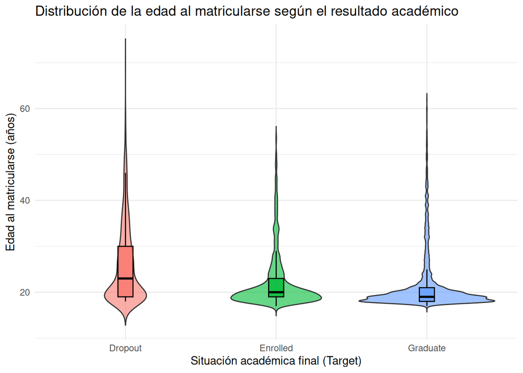

```r
# 2. Gráfico de densidad / violín para visualizar la distribución de edades por Target
ggplot(datos_limpio, aes(x = target, y = age_at_enrollment, fill = target)) +
  geom_violin(trim = FALSE, alpha = 0.6) +
  geom_boxplot(width = 0.1, color = "black", alpha = 0.8, outlier.shape = NA) +
  labs(
    title = "Distribución de la edad al matricularse según el resultado académico",
    x = "Situación académica final (Target)",
    y = "Edad al matricularse (años)"
  ) +
  theme_minimal() +
  theme(legend.position = "none")
```

**Código**

```r
# 3. Relación entre modalidad de asistencia y abandono
tabla_turno <- table(datos_limpio$daytime_evening_attendance, datos_limpio$target)
print("Tabla de contingencia (Modalidad de asistencia vs Target):")
```

```
[1] "Tabla de contingencia (Modalidad de asistencia vs Target):"
```

**Código**

```r
print(tabla_turno)
```

```
             Dropout Enrolled Graduate
  Vespertino     207       75      201
  Diurno        1214      719     2008
```

**Código**

```r
print(chisq.test(tabla_turno))
```

```
    Pearson's Chi-squared test

data:  tabla_turno
X-squared = 28.74, df = 2, p-value = 5.744e-07
```

**Código**

```r
# 4. Modalidad de asistencia: porcentajes por fila y tamaño del efecto
print("Proporciones por filas (%) (Modalidad vs Target):")
```

```
[1] "Proporciones por filas (%) (Modalidad vs Target):"
```

**Código**

```r
print(round(prop.table(tabla_turno, margin = 1) * 100, 2))
```

```
             Dropout Enrolled Graduate
  Vespertino   42.86    15.53    41.61
  Diurno       30.80    18.24    50.95
```

**Código**

```r
cat("V de Cramér (modalidad vs Target):", round(cramers_v(tabla_turno), 3), "\n")
```

```
V de Cramér (modalidad vs Target): 0.081
```

**Código**

```r
# 5. Edad: tamaño del efecto y contraste (Dropout frente a Graduate)
dg_edad <- datos_limpio %>%
  filter(target %in% c("Dropout", "Graduate")) %>%
  droplevels()

cat("d de Cohen (edad, Dropout - Graduate):",
    round(cohen_d(dg_edad$age_at_enrollment, dg_edad$target), 3), "\n")
```

```
d de Cohen (edad, Dropout - Graduate): 0.568
```

**Código**

```r
print(wilcox.test(age_at_enrollment ~ target, data = dg_edad, exact = FALSE))
```

```
    Wilcoxon rank sum test with continuity correction

data:  age_at_enrollment by target
W = 2147125, p-value < 2.2e-16
alternative hypothesis: true location shift is not equal to 0
```

**Código**

```r
# 6. Tasa de abandono por tramos de edad
tasa_edad <- datos_limpio %>%
  mutate(tramo_edad = cut(age_at_enrollment,
                          breaks = c(0, 19, 24, 29, Inf),
                          labels = c("19 o menos", "20-24", "25-29", "30 o más"))) %>%
  group_by(tramo_edad) %>%
  summarise(n = n(), tasa_abandono = mean(target == "Dropout") * 100)

print("Tasa de abandono (%) por tramos de edad:")
```

```
[1] "Tasa de abandono (%) por tramos de edad:"
```

**Código**

```r
print(tasa_edad)
```

```
# A tibble: 4 × 3
  tramo_edad     n tasa_abandono
  <fct>      <int>         <dbl>
1 19 o menos  1952          21.0
2 20-24       1334          28.6
3 25-29        427          57.6
4 30 o más     711          54.1
```

**Resultado y decisión:** La edad media es de 21,8 años en *Graduate*, 22,4 en *Enrolled* y 26,1 en *Dropout*. La diferencia entre abandono y graduación es de tamaño medio (d de Cohen = 0,57; Wilcoxon, p < 0,001) y la tasa de abandono se dispara a partir de los 25 años: 21,0 % (19 o menos), 28,6 % (20-24), 57,6 % (25-29) y 54,1 % (30 o más). La modalidad vespertina también se asocia con más abandono (42,9 % frente al 30,8 % del turno diurno), pero el efecto es pequeño (V de Cramér = 0,08). La edad discrimina bastante mejor que el turno.

## 4.5 Pregunta 5: Sensibilidad al entorno macroeconómico

### Planteamiento y Justificación

Finalmente, evaluamos si el contexto socioeconómico regional representado por el desempleo (`unemployment_rate`), la inflación (`inflation_rate`) y el PIB (`gdp`) ejerce una correlación apreciable en las tasas globales de éxito académico o si, por el contrario, el éxito depende de factores microeconómicos e individuales.

**Código**

```r
# 1. Resumen de variables macroeconómicas agrupadas por estado final del estudiante
resumen_macro <- datos_limpio %>%
  group_by(target) %>%
  summarise(
    media_desempleo = mean(unemployment_rate, na.rm = TRUE),
    media_inflacion = mean(inflation_rate, na.rm = TRUE),
    media_gdp = mean(gdp, na.rm = TRUE)
  )

print("Valores medios macroeconómicos según el estado final del estudiante:")
```

```
[1] "Valores medios macroeconómicos según el estado final del estudiante:"
```

**Código**

```r
print(resumen_macro)
```

```
# A tibble: 3 × 4
  target   media_desempleo media_inflacion media_gdp
  <fct>              <dbl>           <dbl>     <dbl>
1 Dropout             11.6            1.28   -0.151
2 Enrolled            11.3            1.21    0.0533
3 Graduate            11.6            1.20    0.0818
```

**Código**

```r
# 2. Matriz de correlación entre variables macroeconómicas y métricas de rendimiento académico
vars_macro_rendimiento <- datos_limpio %>%
  select(unemployment_rate, inflation_rate, gdp,
         curricular_units_1st_sem_approved, curricular_units_2nd_sem_approved)

matriz_corr_macro <- cor(vars_macro_rendimiento, use = "complete.obs")
print("Matriz de correlación (Macro vs Rendimiento Académico):")
```

```
[1] "Matriz de correlación (Macro vs Rendimiento Académico):"
```

**Código**

```r
print(round(matriz_corr_macro, 3))
```

```
                                  unemployment_rate inflation_rate    gdp
unemployment_rate                             1.000         -0.029 -0.335
inflation_rate                               -0.029          1.000 -0.112
gdp                                          -0.335         -0.112  1.000
curricular_units_1st_sem_approved             0.051         -0.007  0.018
curricular_units_2nd_sem_approved             0.049         -0.025  0.022
                                  curricular_units_1st_sem_approved
unemployment_rate                                             0.051
inflation_rate                                               -0.007
gdp                                                           0.018
curricular_units_1st_sem_approved                             1.000
curricular_units_2nd_sem_approved                             0.904
                                  curricular_units_2nd_sem_approved
unemployment_rate                                             0.049
inflation_rate                                               -0.025
gdp                                                           0.022
curricular_units_1st_sem_approved                             0.904
curricular_units_2nd_sem_approved                             1.000
```

**Código**

```r
# 3. Contraste de Kruskal-Wallis y tamaño del efecto (eta cuadrado basado en H)
vars_macro <- c("unemployment_rate", "inflation_rate", "gdp")

efecto_macro <- map_dfr(vars_macro, function(v) {
  kw <- kruskal.test(datos_limpio[[v]] ~ datos_limpio$target)
  k  <- nlevels(datos_limpio$target)
  n  <- nrow(datos_limpio)
  tibble(variable = v,
         H        = unname(kw$statistic),
         p_valor  = kw$p.value,
         eta2     = (unname(kw$statistic) - k + 1) / (n - k))
})

print("Kruskal-Wallis y tamaño del efecto (macro vs Target):")
```

```
[1] "Kruskal-Wallis y tamaño del efecto (macro vs Target):"
```

**Código**

```r
print(efecto_macro)
```

```
# A tibble: 3 × 4
  variable              H  p_valor      eta2
  <chr>             <dbl>    <dbl>     <dbl>
1 unemployment_rate 12.9  0.00160  0.00246
2 inflation_rate     2.44 0.296    0.0000990
3 gdp               14.4  0.000742 0.00281
```

**Resultado y decisión:** Las medias macroeconómicas son casi idénticas entre los tres grupos (por ejemplo, desempleo del 11,6 %, 11,3 % y 11,6 % en *Dropout*, *Enrolled* y *Graduate*) y sus correlaciones con las asignaturas aprobadas son prácticamente nulas (|r| ≤ 0,05). El contraste de Kruskal-Wallis resulta significativo para el desempleo (p = 0,002) y el PIB (p < 0,001) por el gran tamaño muestral, pero el tamaño del efecto es despreciable (η² ≈ 0,003 en ambos casos), y la inflación ni siquiera es significativa (p = 0,30). Las variables macroeconómicas no explican el abandono de forma relevante.

## 4.6 Combinación de variables y detección temprana

### Planteamiento y Justificación

Las fases 4 y 5 del plan de exploración piden combinar variables y valorar con qué antelación puede detectarse el abandono. Para ello se compara la capacidad de distinguir *Dropout* de *Graduate* (se excluye *Enrolled* por no tener resultado final conocido) de tres modelos de regresión logística con información acumulada: (1) solo variables conocidas en la matrícula, (2) añadiendo el rendimiento del 1.er semestre y (3) añadiendo también el del 2.º semestre. La capacidad se mide con el AUC sobre una partición de prueba del 30 % que no se usa para ajustar los modelos. El objetivo no es construir un modelo final, sino cuantificar cuánto aporta cada fase de información.

**Código**

```r
# 1. Datos y partición entrenamiento / prueba (estratificada por Target)
datos_modelo <- datos_limpio %>%
  filter(target != "Enrolled") %>%
  mutate(abandono = as.integer(target == "Dropout"))

vars_matricula <- c("age_at_enrollment", "admission_grade", "previous_qualification_grade",
                    "gender", "scholarship_holder", "displaced",
                    "daytime_evening_attendance", "application_order")
vars_sem1 <- c("curricular_units_1st_sem_approved", "curricular_units_1st_sem_grade")
vars_sem2 <- c("curricular_units_2nd_sem_approved", "curricular_units_2nd_sem_grade")

set.seed(123)
idx_train <- createDataPartition(factor(datos_modelo$abandono), p = 0.7, list = FALSE)
train <- datos_modelo[idx_train, ]
test  <- datos_modelo[-idx_train, ]
```

**Código**

```r
# 2. AUC de los tres modelos en la muestra de prueba
# AUC = probabilidad de que un estudiante que abandona reciba una puntuación mayor
# que uno que se gradúa (0,5 = azar; 1 = discriminación perfecta)
auc <- function(y, p) {
  r  <- rank(p)
  n1 <- sum(y == 1)
  n0 <- sum(y == 0)
  (sum(r[y == 1]) - n1 * (n1 + 1) / 2) / (n1 * n0)
}

ajustar_auc <- function(vars) {
  modelo <- glm(reformulate(vars, response = "abandono"), data = train, family = binomial)
  auc(test$abandono, predict(modelo, newdata = test, type = "response"))
}

tabla_auc <- tibble(
  modelo = c("1. Solo matrícula", "2. + 1.er semestre", "3. + 2.º semestre"),
  auc    = c(ajustar_auc(vars_matricula),
             ajustar_auc(c(vars_matricula, vars_sem1)),
             ajustar_auc(c(vars_matricula, vars_sem1, vars_sem2)))
)

print("AUC en la muestra de prueba:")
```

```
[1] "AUC en la muestra de prueba:"
```

**Código**

```r
print(tabla_auc)
```

```
# A tibble: 3 × 2
  modelo               auc
  <chr>              <dbl>
1 1. Solo matrícula  0.751
2 2. + 1.er semestre 0.878
3 3. + 2.º semestre  0.909
```

**Resultado y decisión:** El AUC pasa de aproximadamente 0,75-0,78 con la información de la matrícula a 0,87-0,89 al añadir el 1.er semestre y a 0,91-0,92 con el 2.º. Casi todo el salto se produce con el 1.er semestre, mientras que el 2.º aporta poco más. El abandono puede, por tanto, detectarse razonablemente pronto, al terminar el primer semestre, y esperar al segundo apenas mejora la detección. El valor exacto del AUC depende de la partición aleatoria (se fija `set.seed(123)`), por lo que debe leerse como orden de magnitud.

# 5. PRINCIPALES HALLAZGOS Y CONCLUSIONES

A lo largo de este análisis exploratorio de datos (EDA), hemos investigado las dinámicas multidimensionales que condicionan la trayectoria académica de los estudiantes universitarios. A continuación, se sintetizan los resultados más relevantes aportados por la evidencia empírica, junto con las limitaciones metodológicas que deben tenerse en cuenta en su interpretación.

## 5.1 Hallazgos Principales

1. **Distribución de la situación final y desbalance de clases:**
   - **Evidencia:** De los $4.424$ estudiantes, $2.209$ se gradúan ($49{,}9\%$), $1.421$ abandonan ($32{,}1\%$) y $794$ continúan matriculados ($18{,}0\%$). La clase mayoritaria (*Graduate*) es $2{,}78$ veces mayor que la minoritaria (*Enrolled*), y el contraste chi-cuadrado de bondad de ajuste rechaza que las tres clases sean equiprobables ($p\text{-valor} < 0{,}001$). Al excluir *Enrolled*, la tasa de abandono entre los resultados conocidos sube del $32{,}1\%$ al $39{,}1\%$.
   - **Interpretación:** El desbalance es moderado, pero suficiente para que los recuentos absolutos no sean comparables entre grupos, por lo que el resto del análisis se apoya en porcentajes y medidas dentro de cada grupo. Además, como el resultado final de *Enrolled* no se conoce, esta categoría se mantiene en el análisis, pero las conclusiones que dependen de ella deben leerse con cautela.

2. **El umbral crítico del primer semestre frente a la nota de acceso:**

- **Evidencia:** Los datos demuestran que el rendimiento académico temprano es el discriminador más potente del éxito o abandono escolar. Mientras que los estudiantes que se gradúan aprueban una media de $6{,}23$ asignaturas en el primer semestre, aquellos que abandonan (*Dropout*) se sitúan en una media de apenas $2{,}55$ asignaturas aprobadas. En contraste, las diferencias en la nota de admisión universitaria (`Admission grade`) entre ambos grupos son considerablemente menores: en tamaño del efecto (d de Cohen, *Dropout* frente a *Graduate*), el de las asignaturas aprobadas es $|d| = 1{,}37$ y el de la nota de admisión, $0{,}26$. Además, el abandono es del $71$–$79\%$ con $0$–$2$ asignaturas aprobadas y se queda en torno al $10$–$14\%$ a partir de $5$.
- **Interpretación:** La adaptación inicial a la dinámica universitaria y el éxito en los primeros exámenes de septiembre/enero pesan de forma decisiva en la permanencia del estudiante, superando con creces el valor predictivo de las calificaciones obtenidas en la enseñanza secundaria previa.

3. **Impacto crítico de la vulnerabilidad financiera:**

- **Evidencia:** El análisis de contingencia revela una asociación estadísticamente muy significativa ($p\text{-valor} < 0{,}001$) entre el impago de tasas (`Debtor`) y la probabilidad de abandono. El $62{,}0\%$ de los estudiantes con deudas económicas abandona, frente al $28{,}3\%$ de los que están al corriente de pago. La asociación es de tamaño moderado (V de Cramér $= 0{,}24$) y se mantiene al controlar el rendimiento: en la regresión logística (*Dropout* frente a *Graduate*), el impago multiplica por $6{,}4$ las odds de abandono (IC 95 %: $4{,}8$–$8{,}7$) y la beca las reduce (OR $= 0{,}23$).
- **Interpretación:** La restricción económica opera como un factor de vulnerabilidad extremo que multiplica el riesgo de abandono escolar, evidenciando la necesidad de mecanismos institucionales de apoyo financiero y moratorias flexibles.

4. **El perfil demográfico y la edad de matriculación:**

- **Evidencia:** La edad media de los estudiantes que se gradúan se sitúa en torno a los $21{,}8$ años, mientras que en el grupo de abandono asciende hasta los $26{,}1$ años. El efecto es de tamaño medio ($d = 0{,}57$) y el abandono se dispara a partir de los $25$ años ($57{,}6\%$ entre los $25$ y los $29$, frente al $21{,}0\%$ hasta los $19$). La modalidad vespertina también se asocia con más abandono ($42{,}9\%$ frente al $30{,}8\%$ del turno diurno), pero con un efecto pequeño ($V = 0{,}08$).
- **Interpretación:** Los estudiantes de mayor edad suelen enfrentarse a una asincronía temporal derivada de la combinación de estudios con responsabilidades laborales o familiares, lo que reduce su margen de dedicación académica y eleva la tasa de abandono.

5. **Efecto macroeconómico despreciable:**

- **Evidencia:** Las variables macroeconómicas regionales (`Unemployment rate`, `Inflation rate`, `GDP`) muestran medias prácticamente idénticas entre los tres estados de la variable `Target`. Aunque el contraste de Kruskal-Wallis resulta significativo para el desempleo y el PIB por el gran tamaño muestral, el tamaño del efecto es despreciable ($\eta^2 \approx 0{,}003$).
- **Interpretación:** El éxito o fracaso académico en esta cohorte no responde a fluctuaciones coyunturales de la economía general del país, sino primordialmente a factores microeconómicos, institucionales y de rendimiento académico individual.

6. **Capacidad de detección temprana:**

- **Evidencia:** En una muestra de prueba, un modelo logístico que distingue *Dropout* de *Graduate* alcanza un AUC de aproximadamente $0{,}75$–$0{,}78$ usando solo información de la matrícula, de $0{,}87$–$0{,}89$ al añadir el rendimiento del primer semestre y de $0{,}91$–$0{,}92$ al añadir el del segundo.
- **Interpretación:** La mayor parte de la información sobre el riesgo de abandono llega con el primer semestre, por lo que es el momento natural para una alerta temprana; los datos de matrícula por sí solos orientan, pero discriminan bastante peor.

## 5.2 Limitaciones Metodológicas

Las conclusiones obtenidas deben interpretarse bajo el marco de las siguientes restricciones:

- **Naturaleza observacional:** El estudio identifica asociaciones y perfiles de riesgo robustos, pero no permite establecer relaciones de causalidad directa.
- **Sesgo institucional:** Al proceder los datos de una única institución universitaria portuguesa, la generalización de los resultados a otros sistemas educativos o países debe realizarse con cautela.
- **Incertidumbre en la categoría `Enrolled`:** Los estudiantes en curso activo no disponen de un resultado final definitivo dentro de la ventana temporal del dataset.
- **Significación frente a relevancia:** Con $4.424$ observaciones, diferencias mínimas resultan significativas; por ello los contrastes se acompañan del tamaño del efecto.
- **Alcance de la detección temprana:** Los modelos se evalúan en una única partición aleatoria y sin variables como la titulación; sirven para comparar fases de información, no como modelo predictivo definitivo.

# 6. USO DE INTELIGENCIA ARTIFICIAL

En cumplimiento de las directrices académicas de transparencia metodológica, se detalla a continuación el uso, integración y verificación de herramientas de Inteligencia Artificial (IA) empleadas durante el desarrollo de esta práctica:

## 6.1 Tareas en las que se ha Utilizado

- **Soporte metodológico y estructuración:** Orientación en el diseño del plan de trabajo por fases y en la formulación formal de las preguntas de investigación y sus correspondientes objetivos.
- **Generación y depuración de código en R:** Asistencia en la sintaxis de `tidyverse`, `ggplot2` y funciones estadísticas para la limpieza de datos, el cálculo de estadísticos descriptivos y la generación de gráficos de distribución.
- **Diseño de contrastes y modelos:** Asistencia en la elección de medidas de tamaño del efecto (d de Cohen, V de Cramér, η²), contrastes no paramétricos y la regresión logística usada para valorar la detección temprana.
- **Revisión de estilo y redacción académica:** Apoyo en la maquetación en formato Quarto (`.qmd`) y en la estructuración formal del informe técnico.

## 6.2 Integración en el Proceso de Trabajo

La IA se ha integrado como un **asistente de colaboración interactivo**, adoptando un enfoque de supervisión humana constante. El grupo de trabajo ha tomado en todo momento las decisiones estratégicas sobre qué variables analizar, qué hipótesis contrastar y cómo interpretar los resultados empíricos obtenidos del conjunto de datos.

## 6.3 Verificación de la Información, el Código y las Interpretaciones

Para garantizar la máxima rigorosidad científica y evitar alucinaciones o errores técnicos, todo el contenido generado con asistencia de IA ha sido rigurosamente verificado mediante los siguientes filtros:

1. **Verificación empírica del código:** Los scripts de R no se han dado por válidos sin antes ejecutarse de forma independiente sobre el archivo `data.csv`, comprobando que los nombres de las columnas, las dimensiones del dataframe ($4.424 \times 37$) y los resultados numéricos devueltos coincidían exactamente con la realidad estadística de los datos.
2. **Contraste de hipótesis y significación estadística:** Se han revisado los estadísticos devueltos (medias, tablas de contingencia y contrastes de independencia) para asegurar que las interpretaciones ofrecidas en el informe se apoyan estrictamente en la evidencia matemática y no en suposiciones del modelo de lenguaje.
3. **Revisión colegiada del grupo:** Cada integrante del equipo ha validado los apartados teóricos y las conclusiones para asegurar su coherencia con los criterios de evaluación de la asignatura de Inferencia Estadística.